# 2018 JAX Neurogenetics scRNA-seq Analysis Workshop

## How to use this notebook

Code and text are encapsulated in editable "cells".

- Each cell can be "entered" and edited by either double-clicking on the cell or pressing enter when the cell is highlighted in blue.
- Each cell can be executed by pressing `[Shift] + [Enter]` when the cell is highlighted (by either a blue or green outline).
  - Text cells will be rendered when executed.
  - Code cells will run in the background when executed. Code cells can rely on code in other cells that have been executed previously.

## Disclaimer

The single cell RNA-seq analysis ecosystem is expanding rapidly. Analysis best practices and methodologies are an active area of research in the scRNA-seq field.

The analysis techniques in this notebook are just one of many ways to analyze this type of data, though many approaches will be similar or follow a similar flow. Further, what is presented here is amenable for real-time, interactive analysis.

There exist substantially larger and more complex analysis packages that can be used for in-depth or other types of analysis presented here.

## Overview

Today, we will be showing how to do the following:

- Loading in 10X scRNA-seq datasets
- Normalization and filtering
- Dimenionality reduction and Clustering
- Data Visualizaton
- Cluster identification
- Interactive analysis using CellView

## 0. Getting Started

Load up the analysis package.

```python
import numpy as np
import pandas as pd
import scalpel as spl
import matplotlib.pyplot as plt
```

So far, I've tried to keep the available API limited to just what you'll need for this workshop.

```python
help(spl)
```

```
Help on package scalpel:

NAME
    scalpel

DESCRIPTION
    This module contains functions to analysis single cell RNA sequencing expression
    data that is output from cellranger and drop-seq_tools.  The functionality
    includes:

    - create a DataFrame from a 10X genomics count gene-barcode counts matrix
    - select highly variable genes
    - reduce data dimensionality via t-SNE and other methods
    - cluster data in reduced dimensionality space with DBSCAN and HDBSCAN
    - save cluster/t-SNE/expression data in an .Rds file for use in CellView
    - various plotting functionality

    The original author of this module is

        Mohan Bolisetty (mby, mohan.bolisetty@jax.org)

    He wrote these functions in an iPython/Jupyter notebook and I translated them to
    this module so that they can be (a) imported into other scripts in addition to
    notebooks and (b) version controlled.

    An example notebook running these commands can be found here:

        examples/ExampleNotebook.ipynb

    author: Mohan Bolisetty (mohan.bolisetty@jax.org)
    author: Bill Flynn (bill.flynn@jax.org)

PACKAGE CONTENTS
    clust_redux
    common (package)
    identify
    plotting
    qc
    random
    read_write

DATA
    PER_CELL = 0
    PER_GENE = 1
    RANDOMSTATE = <scalpel.random.RandomState object>

FILE
    /home/ubuntu/tools/scalpel/scalpel/__init__.py
```

When using a function, it will often be useful to inspect the function. This can be done by wrapping the function name inside `help(<func_name>)` or by appending a question mark to the end of the function name: `<function_name>?`. For example:

```
spl.read_10X?
# or
help(spl.read_10X)
```

The `scalpel` package also provides a wrapper to save figures easily. By default, the output format is `pdf`, but this can be changed with `savefig(figure, "filename.ext", format="ext")`, e.g. `savefig(figure, "plot.png", format="png")`.

We can choose to save all figures we generate in this notebook with the following toggle:

```python
save_notebook_figures = False #True
```

## 1. Data and QC

Let's load in the data:

```python
data_dir = '../Data/'
counts, feature_data = spl.read_10X(data_dir)
```

Dataset shape: number of genes x number of cells

```python
counts.shape
```

```
(27998, 5173)
```

Take a look at the set of genes:

```python
feature_data.head()
```

|  | Associated.Gene.Name |
| --- | --- |
| ENSMUSG00000051951 | Xkr4 |
| ENSMUSG00000089699 | Gm1992 |
| ENSMUSG00000102343 | Gm37381 |
| ENSMUSG00000025900 | Rp1 |
| ENSMUSG00000109048 | Rp1 |

**Question: How many genes and transcripts did we load in?**

Let's plot the number of transcripts/genes and UMIs here

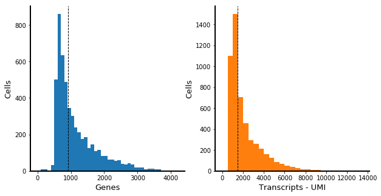

```python
spl.set_plotting_style()

qc_fig = spl.plot_qc(counts)
if save_notebook_figures: spl.savefig(qc_fig, 'QC.pdf')
```

## 2. Filtering and Normalization

Since number of genes and transcipts detected is directly dependent on read depth, library size normalization is essential. This function will normalize gene expression based on total transcripts detected in each cell, multiply with a constant and log transform.

Unlike normal RNA-seq or non-UMI-based scRNA-seq, UMI counts do not need to be normalized for gene length. UMIs uniquely tag each mRNA in a cell, and all reads with a common UMI are collapsed into a single UMI count. In traditional RNA-seq, amplified cDNA is fragmented and the chances of sequencing a fragment from a long transcript is higher than that for short transcripts, making length-normalization needed to correct this bias. However, this bias doesn't exist with 10X chemistry.

```python
cpt = spl.normalize_expression(counts,
                               min_cell_count=500,
                               min_gene_count=2)
```

Here we can use the `min_cell_count` and `min_gene_count` keyword arguments to determine out filtering cutoffs.

- `min_cell_count=N` removes cells with fewer than $N$ transcripts per cell.
- `min_gene_count=M` removes genes wither fewer than $M$ counts in $M$ cells.

**Question: Why should we filter cells out based on transcripts?**

**Question: What kind of genes get exlcluded this way? How many are left?**

**Question: What do the extrema of the expression data look like before and after normalization?**

```python
get_min_max = lambda df: (df.values.min(), df.values.max())
print(get_min_max(counts))
print(get_min_max(cpt))
print(cpt.shape)
```

```
(0, 713)
(0.0, 6.772832257372204)
(10986, 5173)
```

## 3. Feature Selection

One of the most important steps in single cell RNA seq processing, is selecting genes that describe most of the biological variance. However, this is confounded by the high levels of technical noise associated with single cell RNA-seq data.

**The analysis package provides 2 feature selection functions**:

1. `find_variable_genes` - select the top variable genes in the dataset
2. `find_overdispersed_genes` - select the top variable genes in the dataset corrected for technical variance

Choosing the number of features to select is very influential over the remaining downstream analysis. Let's first see how many genes are typically expressed in one of our cells:

```python
spl.median_genes_per_cell(counts)
```

```
912.0
```

```python
n_genes = 500
top_genes = spl.find_overdispersed_genes(cpt, n_genes)
```

Let's take a look at some of those genes

```python
feature_data.loc[top_genes,:].head(10)
```

| gene | Associated.Gene.Name |
| --- | --- |
| ENSMUSG00000031425 | Plp1 |
| ENSMUSG00000061808 | Ttr |
| ENSMUSG00000015090 | Ptgds |
| ENSMUSG00000069917 | Hba-a2 |
| ENSMUSG00000073940 | Hbb-bt |
| ENSMUSG00000018930 | Ccl4 |
| ENSMUSG00000029373 | Pf4 |
| ENSMUSG00000035373 | Ccl7 |
| ENSMUSG00000035385 | Ccl2 |
| ENSMUSG00000058427 | Cxcl2 |

## 4. Dimensionality Reduction

After gene selection, the high dimensionality of single cell RNA-seq data is commnly reduced to cluster similar cells together. The analysis packages currently provides 3 functions for dimensionality reduction:

1. `run_pca`
2. `run_tsne` - for the purposes of the demonstration, we will use t-SNE and reduce data to 3 dimensions
3. `run_umap`

But feel free to use any of these!

```python
redux_data_tsne = spl.run_tsne(cpt, top_genes, tsne_mod='multicore', n_iter=3000, ncores=4)
```

#### An alternative to t-SNE for dimensionality reduction and clustering

In general, t-SNE's low-dimensional embedding does not preserve distances, meaning that relative distances between points (say between A and B and between B and C) in the embedding are not representative of those distances in the original space. That means you cannot make conclusions like "A is closer to B (and thus more similar to B) than C" from just looking at the t-SNE embedding.

`UMAP` is a newer method that, unlike t-SNE, finds a low-dimensional embedding for high-dimensional data that preserves distances. Additionally it has some more intuitive parameters that make tuning the embedding more sensical (as opposed to t-SNE's perplexity) and it is *substantially* faster. However, `UMAP` is still unpublished (as of March 2018) and comprehensive profiling of its performance against t-SNE has yet to be done. That said, I provide it as a drop-in replacement for t-SNE in this package that can be called in an identical way.

```python
redux_data_umap = spl.run_umap(cpt, top_genes, min_dist=0.3)
```

### 4.1 Visualization

Visualization is an important part of an single cell experiment. Exploring data with genes of interest helps validate clustering as wells begins the process of identifying the cell type of each cluster.

First let's look at just the general shape of the embedding.

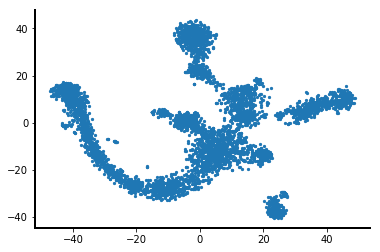

```python
plt.scatter(redux_data_tsne['V1'], redux_data_tsne['V2'], s=5)
```

Really important in single cell RNA-seq is identifying subpopulations of cells by their expression of specific genes. We can get a feel for how that works below.

The function below accepts a single gene and each point representing a cell will be colored by the expression of that gene. Choose from any of the following genes:

- `'Emcn'`
- `'Olig1'`
- `'Olig2'`
- `'Pdgra'`
- `'Fyn'`
- `'Aqp4'`
- `'Mog'`
- `'Slc32a1'`
- `'Slc17a6'`
- `'Cx3cr1'`
- `'Snap25'`
- `'Gfap'`
- `'Gapdh'`

Dimensional axes of the `tsne_data` are `'V1'`, `'V2'`, `'V3'`.

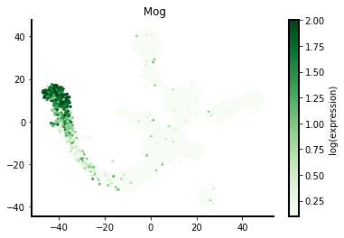

```python
viz_gene = 'Mog'
tsne_gene_fig = spl.plot_expression(cpt, redux_data_tsne, feature_data,
                                    viz_gene, 'V1', 'V2')

if save_notebook_figures: spl.savefig(tsne_gene_fig, f"tSNE-{viz_gene}.pdf")
```

```python
plt.scatter(redux_data_umap['V2'], redux_data_umap['V3'], s=5)
umap_gene_fig = spl.plot_expression(cpt, redux_data_umap, feature_data, viz_gene, 'V2', 'V3', title_prefix='umap')

if save_notebook_figures: spl.savefig(umap_gene_fig, f"umap-{viz_gene}.pdf")
```

[output not shown]

## 5. Cluster identification

After dimensionality reduction, clusters can be identified using a variety of approaches. This analysis package provides 2 density-based functions for clustering of dimensionality-reduced data:

1. `run_dbscan`
2. `run_hdbscan`

We will use the more complex algorithm called HDBSCAN to identify clusters.

```python
cluster_data_tsne = spl.run_hdbscan(redux_data_tsne,
                                    min_cluster_size=40,
                                    min_samples=1)
```

HDBSCAN combines hierarchical clustering and density-based clustering. For typical density-based clustering algoriths, like DBSCAN, you must fine tune how "close" points must be to each other to be considered a cluster. HDBSCAN takes care of this specification by clustering over a variety of density-based clustering parameters, and finds the optimal settings based on 2 factors:

- `min_cluster_size` determines the minimum size of every cluster. Decreasing `min_cluster_size` leads to smaller cluster formation (and thus more clusters).
- `min_samples` determines how conservative cluster assignment is. Decreasing `min_samples` leads to more inclusive clusters, with fewer unclustered points.

Clustering is fast, so feel free to change these parameters and rerun the clustering!

### 5.1 Cluster visualization

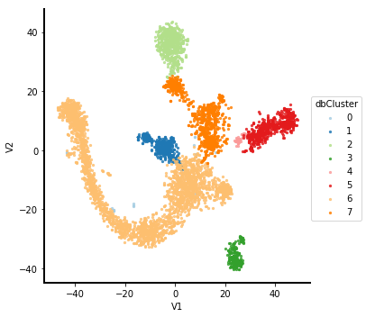

```python
tsne_cluster_fig = spl.plot_clusters(cluster_data_tsne, 'V1', 'V2')
#umap_cluster_fig = spl.plot_clusters(cluster_data_umap, 'V1', 'V3')

if save_notebook_figures:
    spl.savefig(tsne_cluster_fig, "Clusters12.pdf")
```

The analysis package also provides an interactive 3D plot of the clusters (similar to what you may find in CellView):

```python
spl.plot_clusters_3d(cluster_data_tsne, title="TSNE")
```

[interactive chart not shown]

Now that we have identified clusters, we can also plot various quality control metrics for each cluster:

```python
transcripts_fig, genes_fig = spl.plot_qc_violins(cluster_data_tsne, counts)

if save_notebook_figures:
    spl.savefig(transcripts_fig, "TranscriptsByCluster.pdf")
    spl.savefig(genes_fig, "GenesByCluster.pdf")
```

[output not shown]

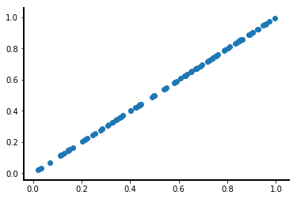

```python
x = np.random.rand(100)
plt.scatter(x, x)
```

## 6. Marker Identification

Identifying genes that differentiate each of these cell populations is an important aspect of single cell RNA-seq data. There are many different methods to do this type of analysis. Given the size of the dataset ome of these are compute heavy. For the sake of brevity, we will use AUROC classification of differentially expressed genes.

```python
help(spl.identify_markers)
```

```python
auc_scores_all = spl.identify_markers(cpt, cluster_data_tsne, feature_data,
                                      fold_change_threshold=1.0)
```

```python
top_markers = []
for k in range(1, cluster_data_tsne.dbCluster.max()):
    mask = auc_scores_all.dbCluster == k
    top_markers.append(auc_scores_all[mask].sort_values('Score').tail(5))
pd.concat(top_markers)
```

|  | Score | Associated.Gene.Name | dbCluster | avgDiff |
| --- | --- | --- | --- | --- |
| ENSMUSG00000031239 | 0.914073 | Itm2a | 1 | 1.465983 |
| ENSMUSG00000018593 | 0.921857 | Sparc | 1 | 1.236167 |
| ENSMUSG00000041378 | 0.922676 | Cldn5 | 1 | 1.532553 |
| ENSMUSG00000023175 | 0.931093 | Bsg | 1 | 2.052776 |
| ENSMUSG00000036256 | 0.953886 | Igfbp7 | 1 | 1.696180 |
| ENSMUSG00000031765 | 0.954334 | Mt1 | 2 | 1.579906 |
| ENSMUSG00000019874 | 0.957281 | Fabp7 | 2 | 1.756649 |
| ENSMUSG00000027447 | 0.978573 | Cst3 | 2 | 2.285433 |
| ENSMUSG00000026385 | 0.980560 | Dbi | 2 | 1.885346 |
| ENSMUSG00000002985 | 0.996253 | Apoe | 2 | 2.816890 |
| ENSMUSG00000021190 | 0.951379 | Lgmn | 3 | 1.452865 |
| ENSMUSG00000036887 | 0.964235 | C1qa | 3 | 1.806514 |
| ENSMUSG00000030579 | 0.968789 | Tyrobp | 3 | 1.664327 |
| ENSMUSG00000036905 | 0.971784 | C1qb | 3 | 1.715720 |
| ENSMUSG00000036896 | 0.991720 | C1qc | 3 | 2.050581 |
| ENSMUSG00000001506 | 0.964007 | Col1a1 | 4 | 1.730619 |
| ENSMUSG00000068220 | 0.966814 | Lgals1 | 4 | 1.613606 |
| ENSMUSG00000029838 | 0.973336 | Ptn | 4 | 1.540358 |
| ENSMUSG00000029661 | 0.981222 | Col1a2 | 4 | 2.012683 |
| ENSMUSG00000026043 | 0.999728 | Col3a1 | 4 | 2.078570 |
| ENSMUSG00000090223 | 0.896886 | Pcp4 | 5 | 1.663237 |
| ENSMUSG00000032532 | 0.910805 | Cck | 5 | 1.125830 |
| ENSMUSG00000032854 | 0.753800 | Ugt8a | 6 | 1.189820 |
| ENSMUSG00000031425 | 0.761877 | Plp1 | 6 | 2.936372 |
| ENSMUSG00000041607 | 0.762623 | Mbp | 6 | 1.801583 |
| ENSMUSG00000006782 | 0.797239 | Cnp | 6 | 1.510401 |
| ENSMUSG00000015149 | 0.805451 | Sirt2 | 6 | 1.308660 |

Note that expression in this package is quantified using `log = ln = natural log`, not `log2` or `log10`.

If any markers are identified, let's plot 'em!

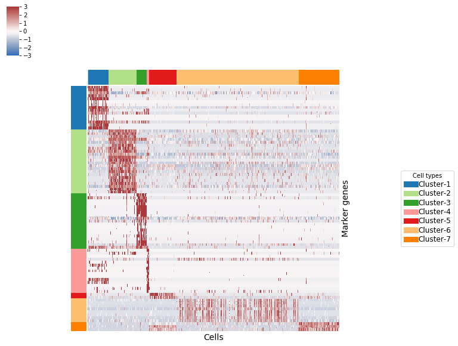

```python
marker_fig = spl.plot_marker_heatmap(cpt, auc_scores_all,
                                     cluster_data_tsne, feature_data)
if save_notebook_figures: spl.savefig(marker_fig, 'MarkerHeatmap.png', format='png')
```

## 7. Make .Rds file for CellView

And finally, let's summarize this analysis into an .Rds file that we can share with others. As of now, this will always save to `Data.Rds`.

```python
spl.write_rds(cpt, feature_data, cluster_data_tsne,
              counts, data_dir)
```

This file can then be downloaded by selecting it in the Jupyter Browser and selecting the "Download" button. We can then upload it for further interactive analysis in [**CellView** (click me)](http://ctshiny01.jax.org:3838/mby/CellView/).